# HSC Survey Results

# German Bank Survey # 3B Results from 08/09/2024

## Survey Details

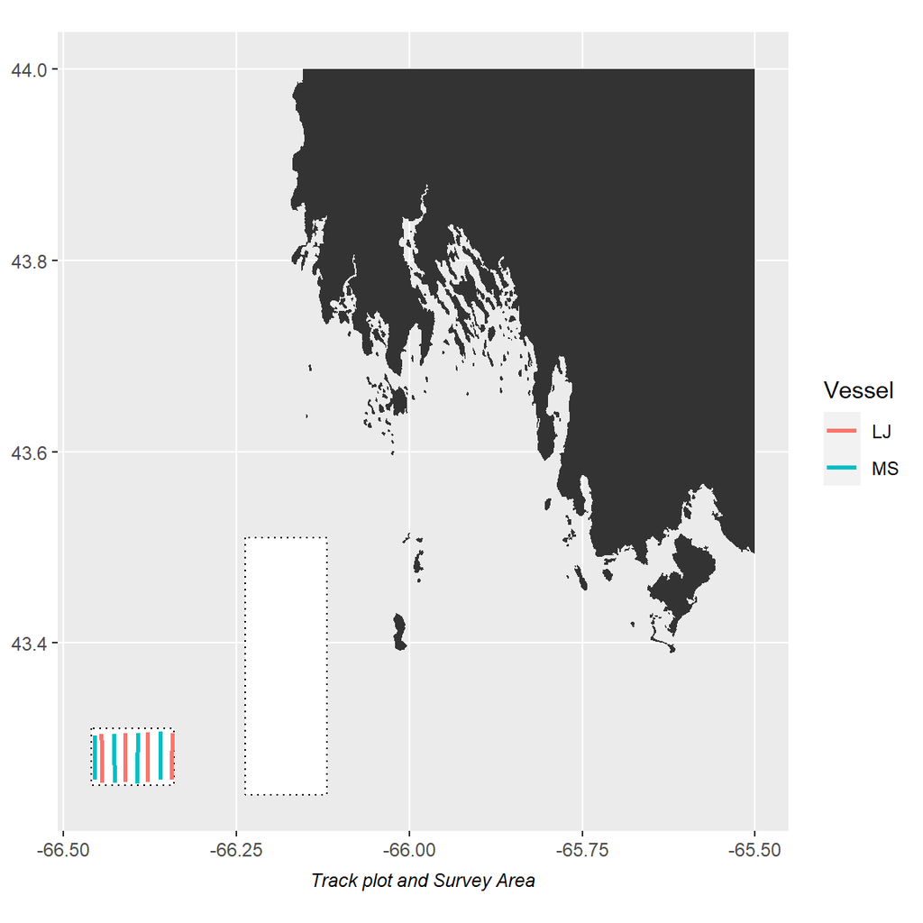

This was an adhoc survey. Both vessels completed 4 lines that were a minimum of 3 nautical miles in length..

There was no plankton tow or CTD cast conducted.

No tags were applied during this survey.

Samples were obtained for target strength estimation.

### Acoustic Equipment

Each vessel was equipped with a Simrad ES38-18/200-18C combi (2-in-1) transducer prior to the survey that contains a 38kHz split beam and 200 kHz single beam transducer. Data was logged to the computer hard-drive for post-processing. All participating boats were calibrated on 38kHz before the survey.

## Survey Results

### Main Results

The results are subject to change as DFO will re-evaluate data editing, area estimation and apply a target strength.

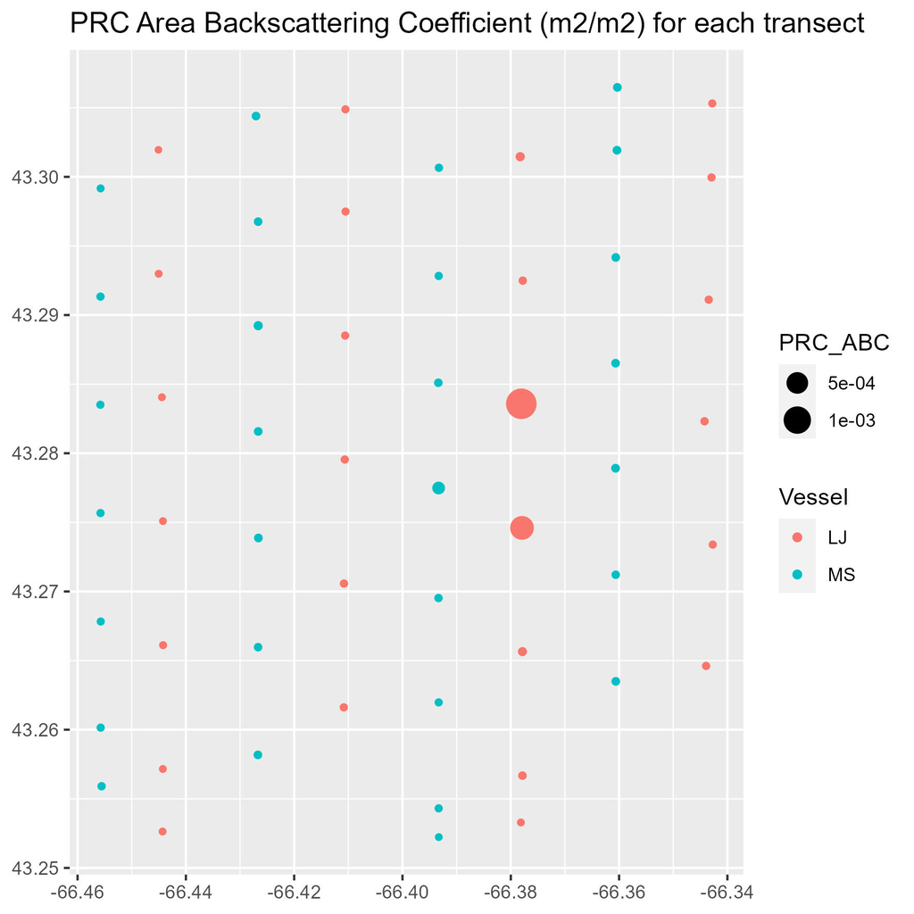

### Transect Details

Table 1: Transect Details

| Vessel | Transect # | Date/Time Start | Date/Time End | Start Lon | Start Lat | End Lon | End Lat | Location | Distance (km) | Speed |
| --- | --- | --- | --- | --- | --- | --- | --- | --- | --- | --- |
| LJ | T01 | 2024-09-08 21:54:53 | 2024-09-08 22:17:30 | -66.445 | 43.304 | -66.444 | 43.253 | GB | 5.75 | 8.23 |
| LJ | T02 | 2024-09-08 21:22:47 | 2024-09-08 21:45:06 | -66.411 | 43.253 | -66.411 | 43.305 | GB | 5.77 | 8.38 |
| LJ | T03 | 2024-09-08 20:49:56 | 2024-09-08 21:13:46 | -66.378 | 43.306 | -66.378 | 43.253 | GB | 5.85 | 7.95 |
| LJ | T04 | 2024-09-08 20:17:03 | 2024-09-08 20:39:21 | -66.344 | 43.256 | -66.343 | 43.305 | GB | 5.59 | 8.12 |
| MS | T01 | 2024-09-08 20:19:23 | 2024-09-08 20:44:28 | -66.361 | 43.256 | -66.360 | 43.306 | GB | 6.57 | 8.48 |
| MS | T02 | 2024-09-08 20:55:20 | 2024-09-08 21:18:52 | -66.393 | 43.305 | -66.393 | 43.252 | GB | 6.79 | 9.34 |
| MS | T03 | 2024-09-08 21:29:38 | 2024-09-08 21:53:48 | -66.426 | 43.253 | -66.427 | 43.304 | GB | 6.69 | 8.97 |
| MS | T04 | 2024-09-08 22:02:43 | 2024-09-08 22:22:43 | -66.455 | 43.302 | -66.456 | 43.256 | GB | 5.98 | 9.69 |

### Survey Summary

Table 2: Acoustic Survey Results

| Vessel | Transect No. | Target Strength (db/kg) | Mean Sa (/m2) | Biomass Density (kg/m2) |
| --- | --- | --- | --- | --- |
| LJ | T03 | -35.5 | -34.501 | 1.259 |
| MS | T02 | -35.5 | -49.477 | 0.040 |
| MS | T03 | -35.5 | -54.278 | 0.013 |
| MS | T01 | -35.5 | -54.520 | 0.013 |
| LJ | T04 | -35.5 | -58.767 | 0.005 |
| LJ | T02 | -35.5 | -58.860 | 0.005 |
| MS | T04 | -35.5 | -59.072 | 0.004 |
| LJ | T01 | -35.5 | -63.590 | 0.002 |

Note:  
Transects are listed from greatest to least backscatter.

Table 3: Survey Summary Table

| Layer | Target Strength | Area (km2) | Mean Sa | Density (kg/m2) | Biomass (tons) | Percent Area | Percent Biomass | Standard Error (tons) | Standard Error (%) |
| --- | --- | --- | --- | --- | --- | --- | --- | --- | --- |
| German Bank | -35.5 | 64.94738 | -43.4304 | 0.1675 | 10,459.85 | 100 | 100 | 10,127.41 | 96.82 |

### Greatest Biomass Densities

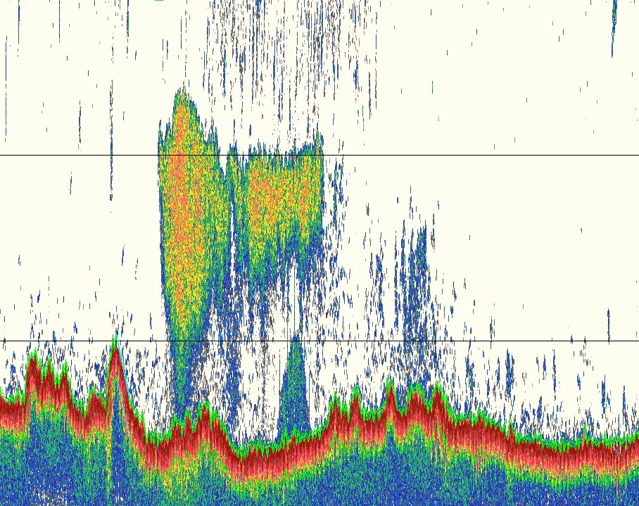

A snip from the transect with the greatest biomass density (kg/m2)

The single point with the largest biomass density (kg/m2) was recorded by **LJ**, at the following location:

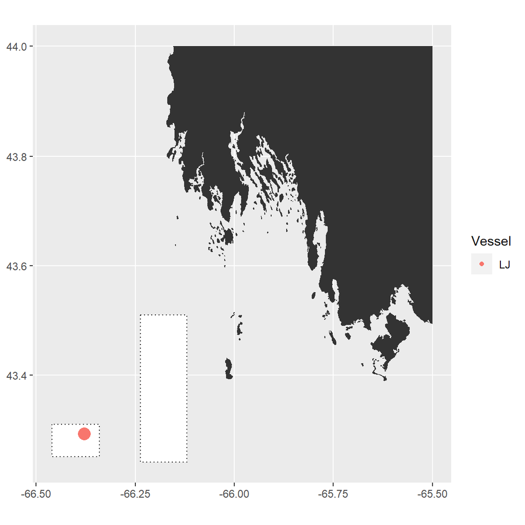

The transect with the greatest average biomass density (kg/m2) was recorded by **LJ**, at the following location:

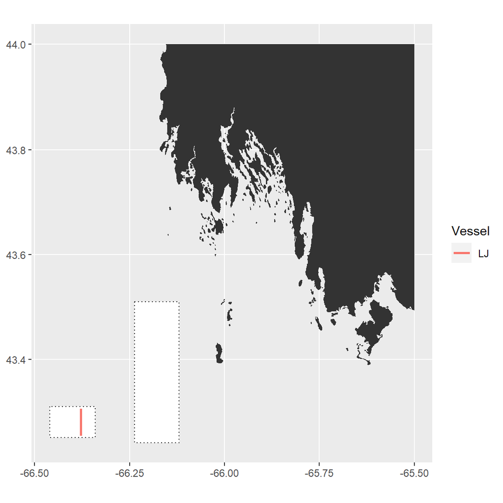

### Annual Summaries

This table does not include the biomass from adhoc surveys.

Table 4: Annual Comparison Table

| Ground | Survey Number | Current Year Survey Date | Current Year HSC Estimate | Current Year HSC Turnover Adjusted | Previous Year Survey Date | Previous Year HSC Estimate | Previous Year HSC Turnover Adjusted | Previous Year DFO Estimate | Previous Year DFO Turnover Adjusted |
| --- | --- | --- | --- | --- | --- | --- | --- | --- | --- |
| German Bank | 1 | 2024-08-04 | 12,233 | 12,233 | 2023-08-06 | 2,687 | 2,687 | 2,021 | 2,021 |
| Seal Island | 1 | 2024-08-04 | 45,930 | NA | 2023-08-06 | 1,205 | NA | 929 | NA |
| German Bank | 2 | 2024-08-18 | 14,054 | 11,668 | 2023-08-20 | 4,930 | 4,406 | 3,282 | 2,887 |
| Seal Island | 2 | 2024-08-18 | 6,285 | NA | 2023-08-20 | 1,918 | NA | 897 | NA |
| German Bank | 3 | 2024-09-02 | 15,499 | 12,639 | 2023-09-03 | 9,959 | 8,901 | 8,372 | 7,660 |
| Seal Island | 3 | 2024-09-02 | 3,770 | NA | 2023-09-03 | 2,063 | NA | 1,099 | NA |
| German Bank | 4 | 2024-09-15 | 24,824 | 21,033 | 2023-09-13 | 16,266 | 13,203 | 15,011 | 12,498 |
| Seal Island | 4 | 2024-09-15 | 1,369 | NA | 2023-09-13 | 5,636 | NA | 4,045 | NA |
| German Bank | 5 | NA | NA | NA | 2023-09-27 | 15,242 | 11,360 | 13,503 | 9,978 |
| Seal Island | 5 | NA | NA | NA | 2023-09-27 | 53,844 | NA | 42,269 | NA |
| German Bank | 6 | NA | NA | NA | 2023-10-11 | 23,614 | 20,057 | 26,563 | 23,390 |
| Seal Island | 6 | NA | NA | NA | 2023-10-11 | 15,261 | NA | 14,381 | NA |
| German Bank | 7 | NA | NA | NA | 2023-10-24 | 11,184 | 5,502 | 13,033 | 6,803 |
| Seal Island | 7 | NA | NA | NA | 2023-10-24 | 1,006 | NA | 1,087 | NA |

Table 5: Annual Summary Table

| Year | Ground | HSC Estimate | HSC Turnover Adjusted | DFO Estimate | DFO Turnover Adjusted |
| --- | --- | --- | --- | --- | --- |
| 2023 | German Bank | 83,882 | 66,116 | 81,785 | 65,237 |
| 2023 | Seal Island | 80,933 | NA | 64,707 | NA |
| 2024 | German Bank | 66,610 | 57,573 | NA | NA |
| 2024 | Seal Island | 57,354 | NA | NA | NA |

## Tagging, Plankton, and CTD Data

### Summary map

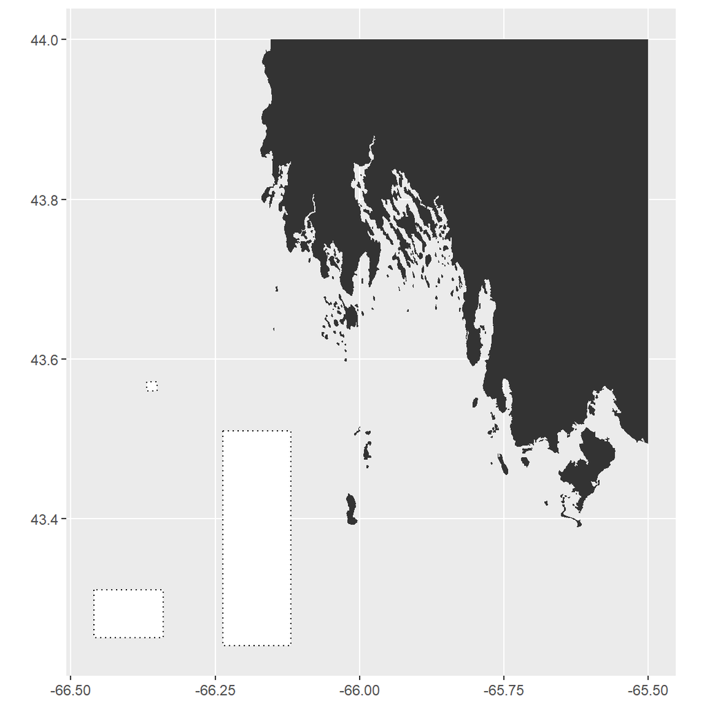

| Vessel | Tags |
| --- | --- |

### CTD Data

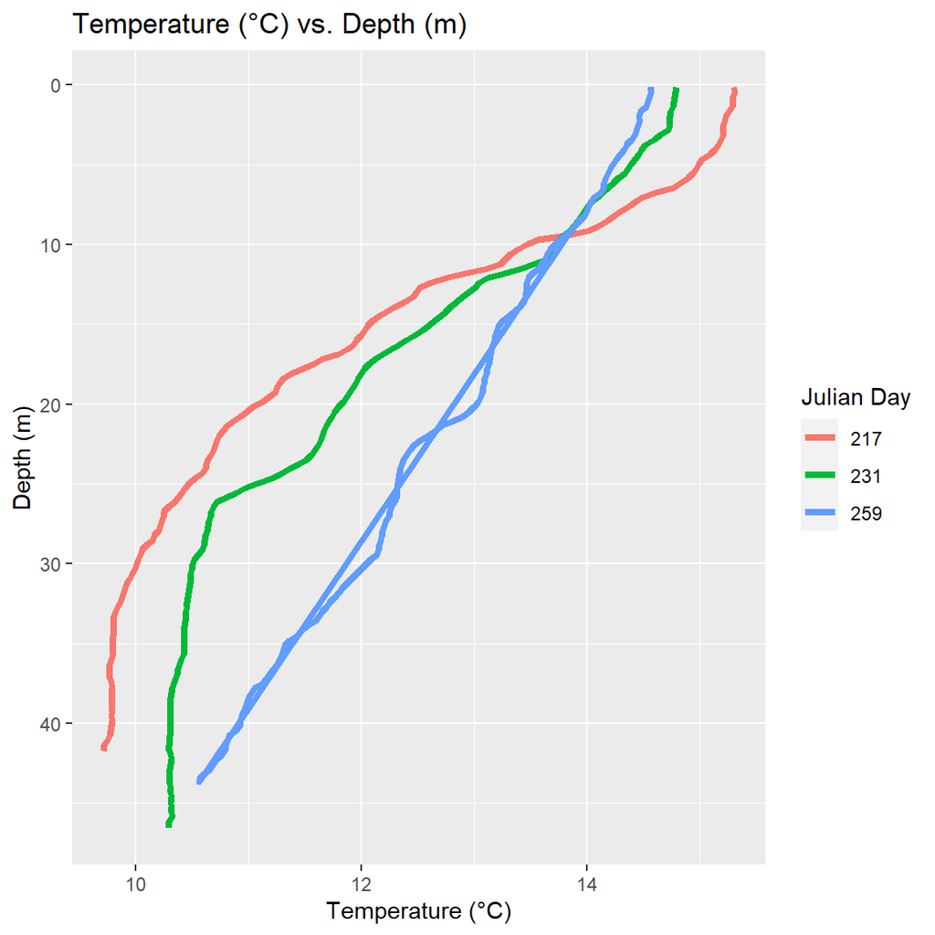

#### Sea surface temperatures

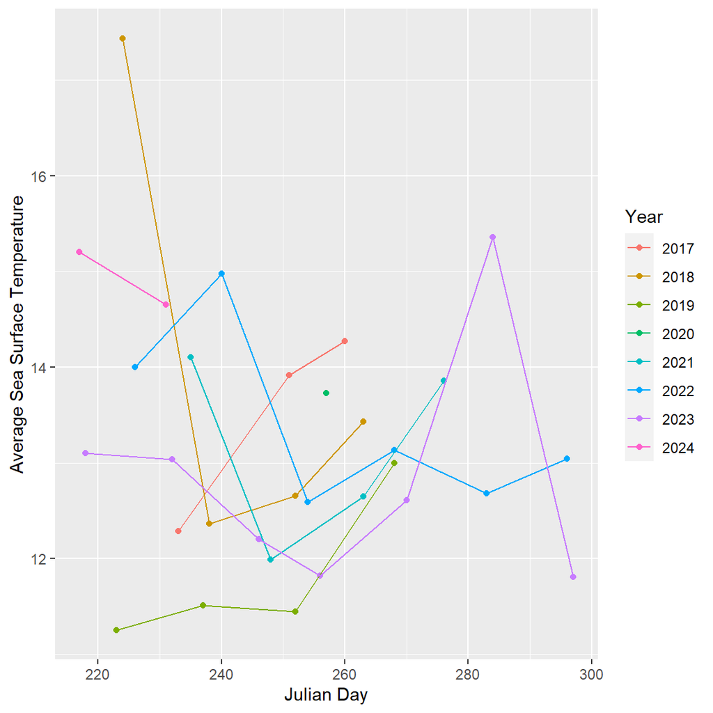

Annual average sea surface temperatures (SST) for German Bank.

## Vessel Performance

### Speed

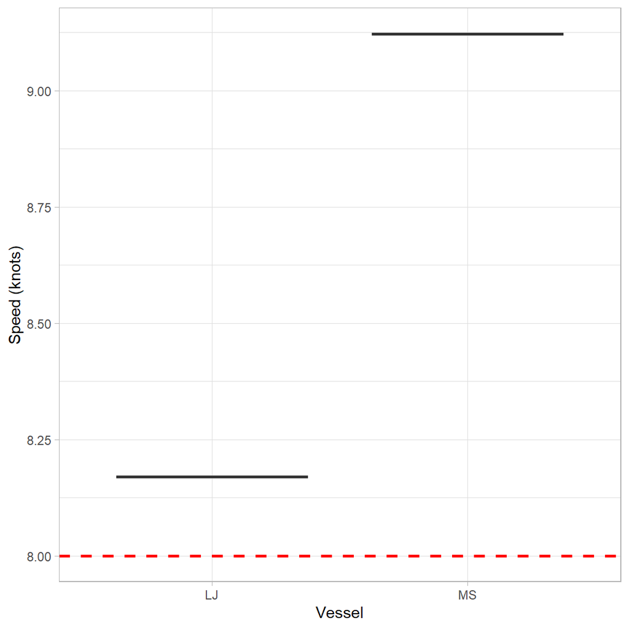

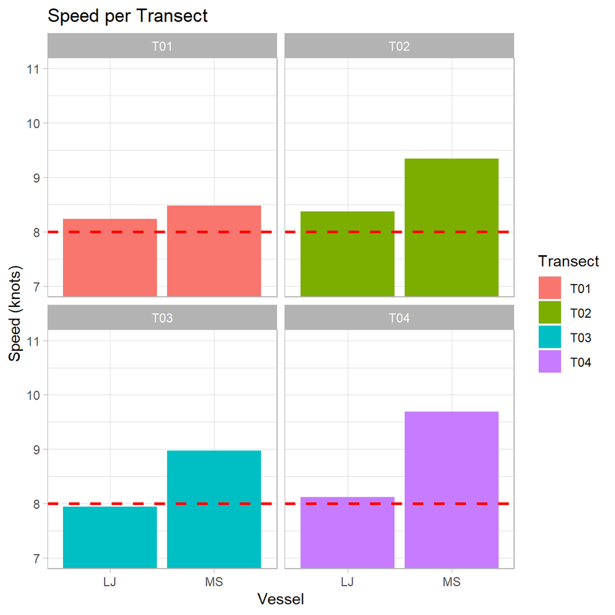

Average vessel speed was 8.65. This is above the 8 knot requirement; vessels are urged to slow down to prevent backscatter noise from interfering with the acoustic data.

The speed for each transect are rudimentary and are calculated based on distance. If a significant amount of distance is cut, the speed will appear slower.